# Participant characteristics: missingness audit

eda

characteristics

Descriptive audit of missing values in the cleaned participant characteristics file, including variable-level rates, participant-level burden, and core clinical coverage.

Author

IBD Capstone team

Published

June 16, 2026

## 1 Overview

This post documents **missingness** in `data/processed/cleaned_characteristics.csv` after the cleaning pipeline in `src/characteristics/characteristics.R`. The goal is descriptive: quantify where data are absent, which variable groups are most affected, and how complete the cohort is on fields used in downstream analyses. No hypothesis test is performed.

> Figures generated by `src/characteristics/01_missingness_eda.R` via `make characteristics`.

## 2 Data

- **Unit of analysis:** Participant (one row per survey record in the characteristics file).
- **Input:** `data/processed/cleaned_characteristics.csv` (`make characteristics` on `data/raw/SYN_Participant Characteristics.xlsx`).
- **Scope:** All 146 columns after cleaning, including demographics, IBD clinical scores, symptom-frequency items, food-avoidance blocks, and ancillary survey fields.

**Cohort size:** 12 participants, 146 variables.

**Columns with no missing values:** 128 (87.7% of variables).

**Median participant missingness:** 9.9% of variables missing per person (max 11.6%).

## 3 Methods

| Item | Choice |
| --- | --- |
| Missing definition | `NA` after cleaning (blank cells, failed coercion, or scrubbed impossible values) |
| Column summaries | Count and percent missing per variable |
| Participant summaries | Percent of variables missing per participant |
| Variable grouping | Rule-based labels (demographics, IBD clinical, symptom frequency, food avoidance, etc.) |
| Statistical test | None — exploratory audit only |

## 4 Figures

### 4.1 Missingness bands across variables

How many columns fall into each missingness range.

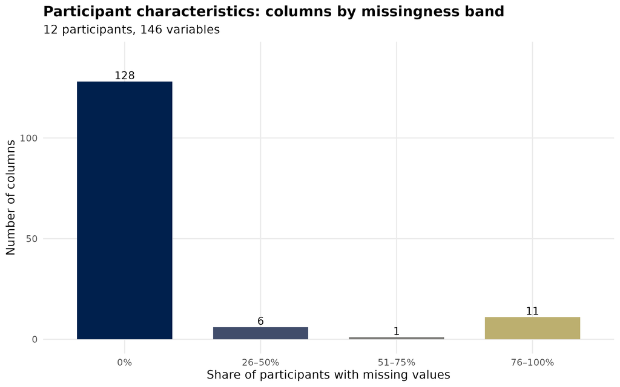

### 4.2 Variable-level missing rates

All variables with at least one missing value, coloured by survey domain.

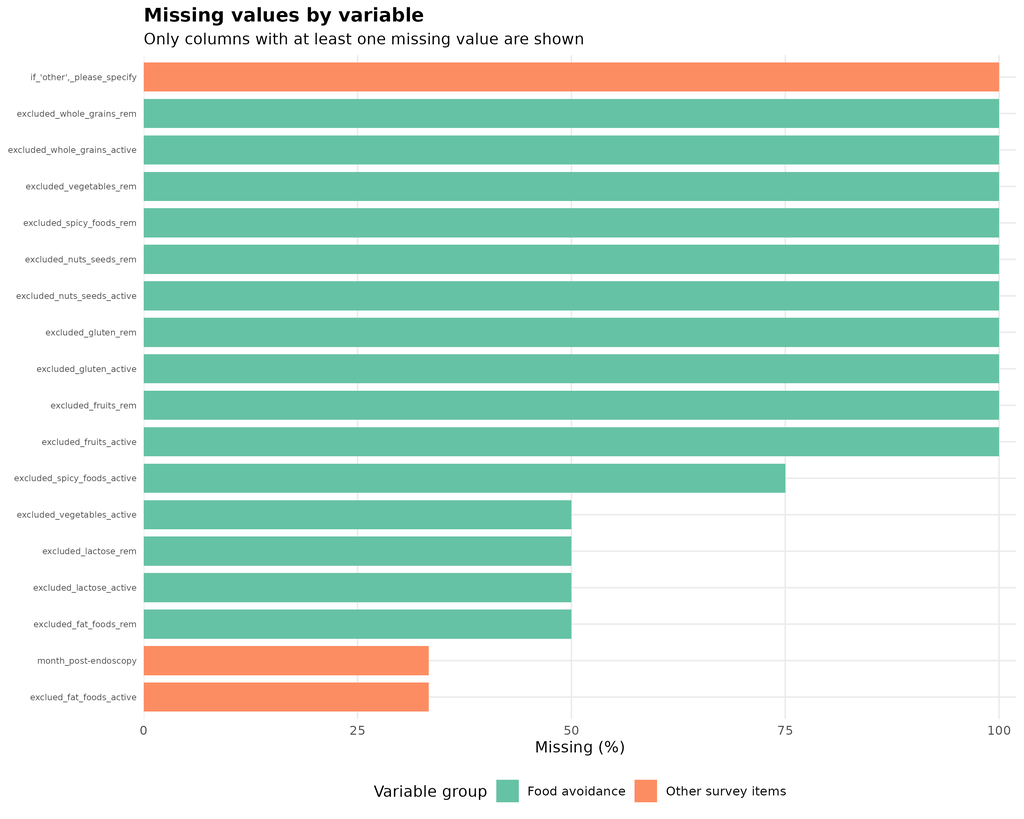

### 4.3 Participant-level burden

Distribution of how many variables are missing per participant.

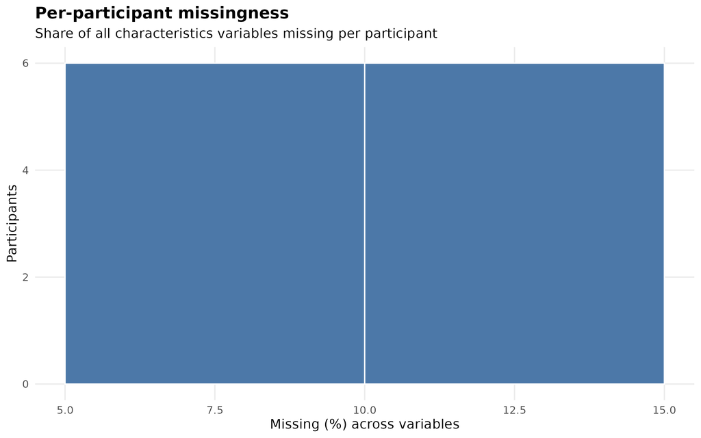

### 4.4 Core clinical and demographic fields

Missingness pattern for fields most often used in symptom and cohort summaries.

[figure not shown]

## 5 Highest-missing variables

| Variable | Missing n | Missing % |
| --- | --- | --- |
| excluded_fruits_active | 12 | 100 |
| excluded_fruits_rem | 12 | 100 |
| excluded_gluten_active | 12 | 100 |
| excluded_gluten_rem | 12 | 100 |
| excluded_nuts_seeds_active | 12 | 100 |
| excluded_nuts_seeds_rem | 12 | 100 |
| excluded_spicy_foods_rem | 12 | 100 |
| excluded_vegetables_rem | 12 | 100 |
| excluded_whole_grains_active | 12 | 100 |
| excluded_whole_grains_rem | 12 | 100 |
| if_‘other’,_please_specify | 12 | 100 |
| excluded_spicy_foods_active | 9 | 75 |
| excluded_fat_foods_rem | 6 | 50 |
| excluded_lactose_active | 6 | 50 |
| excluded_lactose_rem | 6 | 50 |

## 7 Reproducibility

- **Cleaning:** `src/characteristics/characteristics.R`
- **Missingness figures:** `src/characteristics/01_missingness_eda.R`
- **Rendered:** `make characteristics` then `quarto render stats` from repository root